# Problem Set 2 - College Admissions Data

SI 544 Instruction Team

10/25/2019

## Introduction

The total score for this assignment will be 100 points, consisting of: - 90 points: Homework Questions - 10 points: Overall quality of spelling, grammar, punctuation, etc. of written sentences.

As in lecture and discussion, there are several ways to approach and answer these questions! There may not be a “best solution”, but instead a variety of ways to interpret and analyze a given task. Be thoughtful in your responses below your code to explain why you chose the methods and representations in your analysis when prompted for a response.

For further reference regarding quality writing, feel free to refer to Strunk & White’s Elements of Style: https://drive.google.com/file/d/1L0P7xJwjUGBvyb49mL3dw1Bt7hzRTiTl/view?usp=sharing

## The Data

The data set for this assignment consists of college admissions data. It comes from an open data set available via https://www.kaggle.com/mohansacharya/graduate-admissions .

The dataset contains several parameters which are considered important during the application for Masters Programs. The parameters included are:

1. GRE Scores ( out of 340 )
2. TOEFL Scores ( out of 120 )
3. University Rating ( out of 5 )
4. Statement of Purpose and Letter of Recommendation Strength ( out of 5 )
5. Undergraduate GPA ( out of 10 )
6. Research Experience ( either 0 or 1 )
7. Chance of Admit ( ranging from 0 to 1 )

The full citation for the data is:

Mohan S Acharya, Asfia Armaan, Aneeta S Antony : A Comparison of Regression Models for Prediction of Graduate Admissions, IEEE International Conference on Computational Intelligence in Data Science 2019.

Copy the file ‘Admission_Predict.csv’ from the read only folder into your working directory, fill in your name into the string assigned to *MY_UNIQNAME* , then execute the following code block to load the packages and data into your environment.

```r
MY_UNIQNAME = "cginiel"

# Initial setup for our environment
library(tidyverse)
```

```r
library(moderndive)
library(ggplot2)

# Reading the file in from your working directory
data <- read_csv('Admission_Predict.csv')
data <- data %>% select(gre = "GRE Score", toefl = "TOEFL Score", university_rating = `University Rating`, sop = SOP, lor = LOR, cgpa = CGPA, research=Research,admit = `Chance of Admit`) %>% mutate(research=factor(research))
```

### Question 1 (5 points)

Explain what the previous R code block does.

#### Q1 Response:

The previous R code block (above) selects columns from our dataset and displays only those columns, with their names modified as a way to make coding with them easier. For example, “GRE Score” is renamed to gre. The mutate function has a factor function within it, making the “research” column our categorical variable. You can see that R knows this based on the glimpse(data) function below, where research is labeled as ‘fct’.

```r
admissions_data <- data

glimpse(admissions_data)
```

```
## Observations: 400
## Variables: 8
## $ gre               <dbl> 337, 324, 316, 322, 314, 330, 321, 308, 302, 3…
## $ toefl             <dbl> 118, 107, 104, 110, 103, 115, 109, 101, 102, 1…
## $ university_rating <dbl> 4, 4, 3, 3, 2, 5, 3, 2, 1, 3, 3, 4, 4, 3, 3, 3…
## $ sop               <dbl> 4.5, 4.0, 3.0, 3.5, 2.0, 4.5, 3.0, 3.0, 2.0, 3…
## $ lor               <dbl> 4.5, 4.5, 3.5, 2.5, 3.0, 3.0, 4.0, 4.0, 1.5, 3…
## $ cgpa              <dbl> 9.65, 8.87, 8.00, 8.67, 8.21, 9.34, 8.20, 7.90…
## $ research          <fct> 1, 1, 1, 1, 0, 1, 1, 0, 0, 0, 1, 1, 1, 1, 1, 0…
## $ admit             <dbl> 0.92, 0.76, 0.72, 0.80, 0.65, 0.90, 0.75, 0.68…
```

### Question 2 (10 points)

Describe the shape of the distribution of the chance of admission. If you decide to use a histogram choose your width of your bins carefully.

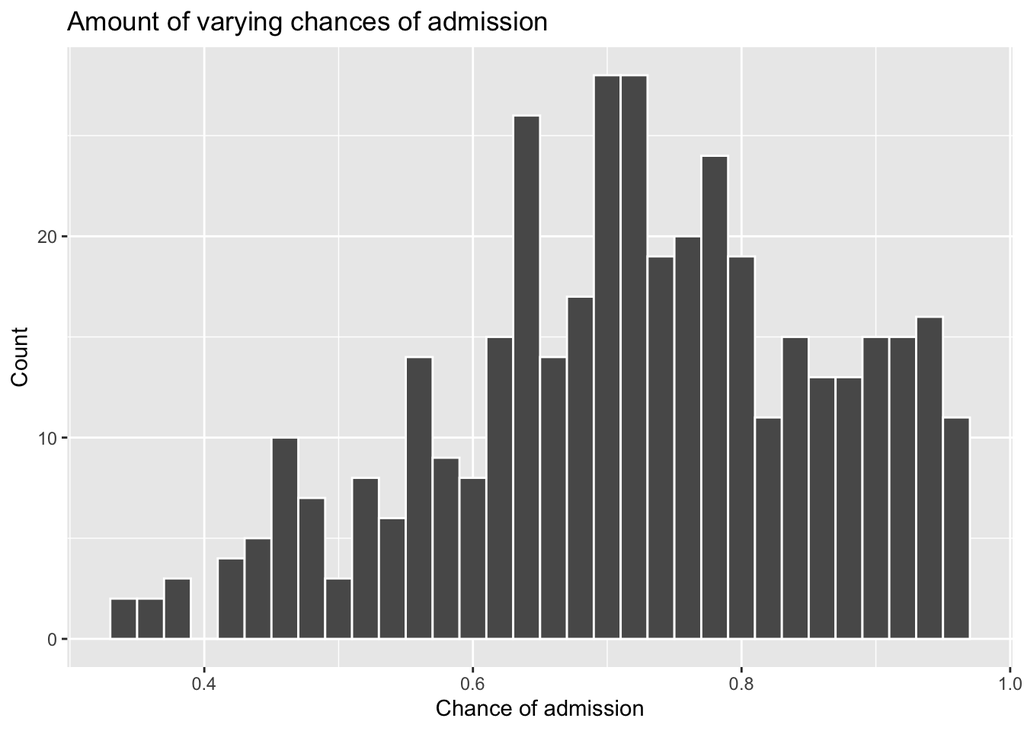

```r
ggplot(admissions_data, aes(x = admit)) +
  xlab("Chance of admission") +
  ylab("Count") +
  labs(title = "Amount of varying chances of admission") +
  geom_histogram(binwidth = .02, col = "white")
```

### Question 3 (10 points)

Create a plot of chance of admission as the outcome variable vs. GRE score as the explanatory variable that shows the line of best fit. Label your axes and use a title or caption for the visualization. Does the lowest GRE score have the least chance of admission?

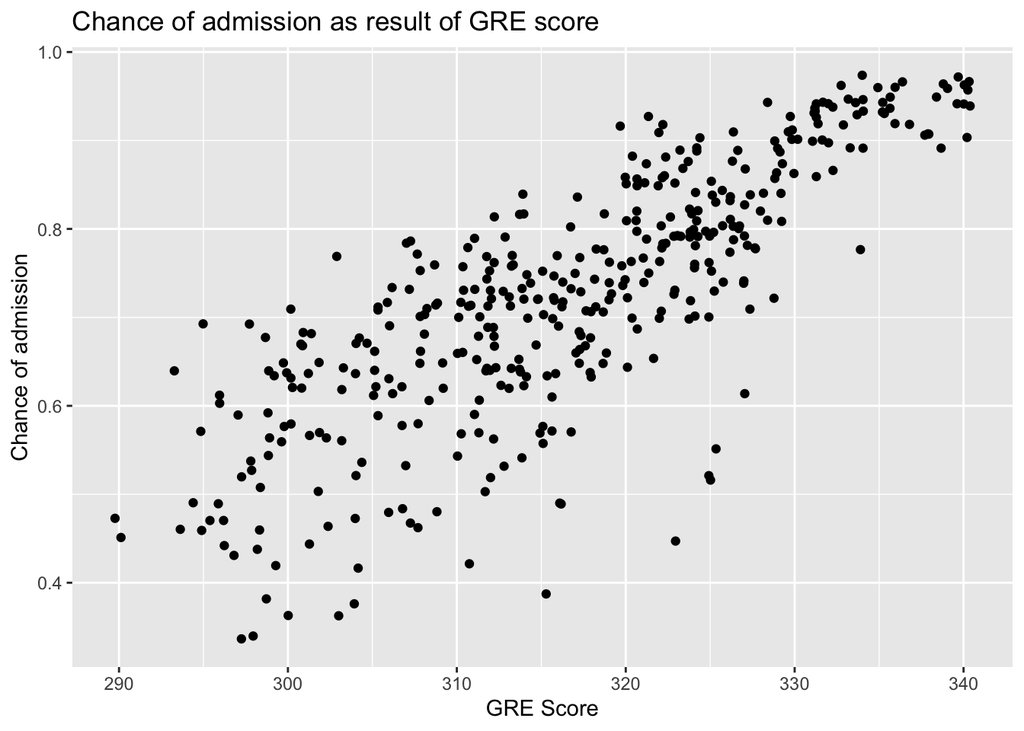

```r
ggplot(admissions_data, aes(x = gre, y = admit)) +
  xlab("GRE Score") +
  ylab("Chance of admission") +
  labs(title = "Chance of admission as result of GRE score") +
  geom_jitter()
```

```r
lowest_gre <- admissions_data %>%
  group_by(gre) %>%
  select(gre, admit) %>%
  arrange(gre)
lowest_gre
```

```
## # A tibble: 400 x 2
## # Groups:   gre [49]
##      gre admit
##    <dbl> <dbl>
##  1   290 0.45
##  2   290 0.47
##  3   293 0.64
##  4   294 0.46
##  5   294 0.49
##  6   295 0.46
##  7   295 0.570
##  8   295 0.69
##  9   295 0.47
## 10   296 0.44
## # … with 390 more rows
```

```r
lowest_admit <- admissions_data %>%
  group_by(admit) %>%
  select(gre, admit) %>%
  arrange(admit)
lowest_admit
```

```
## # A tibble: 400 x 2
## # Groups:   admit [60]
##      gre admit
##    <dbl> <dbl>
##  1   298  0.34
##  2   297  0.34
##  3   300  0.36
##  4   303  0.36
##  5   299  0.38
##  6   304  0.38
##  7   315  0.39
##  8   311  0.42
##  9   304  0.42
## 10   299  0.42
## # … with 390 more rows
```

#### Q3 Response:

No, the lowest GRE score does not have the least chance of admission. The lowest GRE score (290) has a 45% chance of admission. The lowest chance of admission (34%) has a GRE score of 298. (Also, I jittered the points after using geom_point(alpha = 0.2) and discovering there were some overlapping points.)

### Question 4 (15 points)

Create a regression model using chance of admission as the outcome variable and GRE score as the explanatory variable. What are the estimates for the coefficients (intercept and GRE score)?

```r
admissions_data_regression_table <- get_regression_table(lm(admit ~ gre, admissions_data))

admissions_data_regression_table
```

```
## # A tibble: 2 x 7
##   term      estimate std_error statistic p_value lower_ci upper_ci
##   <chr>        <dbl>     <dbl>     <dbl>   <dbl>    <dbl>    <dbl>
## 1 intercept    -2.44     0.118     -20.7       0   -2.67    -2.20
## 2 gre           0.01     0          26.8       0    0.009    0.011
```

```r
admissions_data_slope <- admissions_data_regression_table$estimate[2]
admissions_data_slope
```

```
## [1] 0.01
```

```r
admissions_data_intercept <- admissions_data_regression_table$estimate[1]
admissions_data_intercept
```

```
## [1] -2.436
```

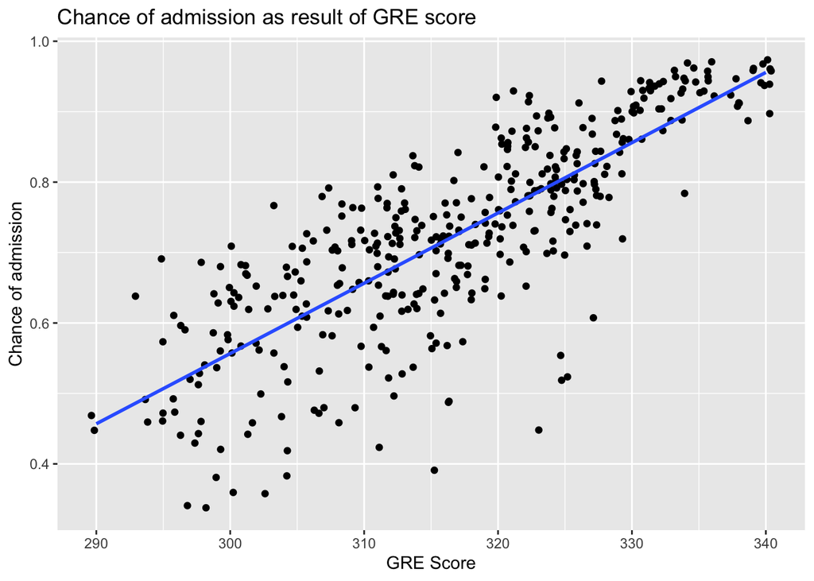

```r
ggplot(admissions_data, aes(x = gre, y = admit)) +
  xlab("GRE Score") +
  ylab("Chance of admission") +
  labs(title = "Chance of admission as result of GRE score") +
  geom_jitter() +
  geom_smooth(method="lm",se=FALSE)
```

#### Q4 Response:

The estimate for the intercept is -2.436. (Which, considering where our data lies, isn’t super helpful for this visualization. I don’t even think you can score a 0 on the GRE.) The slope is 0.01 (in percent chance of admission).

### Question 5 (10 points)

Create a visualization that shows the relationship between Cumulative GPA and the Chance of Admission.  
Use two different colors of lines to show the difference that having research experience makes.  
Describe the effect that having research experience appears to have.

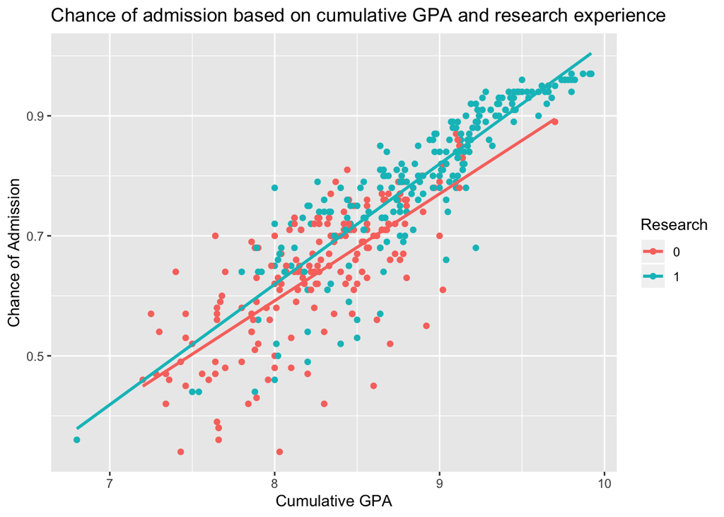

```r
ggplot(admissions_data, aes(x = cgpa, y = admit, color = research)) +
  geom_point() +
  xlab("Cumulative GPA") +
  ylab("Chance of Admission") +
  labs(title = "Chance of admission based on cumulative GPA and research experience", color = "Research") +
  geom_smooth(method="lm",se=FALSE)
```

#### Q5 Response:

Students with research experience 1) tend to have higher cumulative GPAs and 2) tend to have a higher chance of admission.

### Question 6 (15 points)

Create a regression model that uses chance of admission as the outcome variable and Cumulative GPA *and* research experience as the explanatory variables. What is the expected (estimated) value of the chance of admission for an individual with a cumulative GPA of 9.0 who has research experience?

```r
admissions_model_interaction <- lm(admit ~ cgpa * research, admissions_data)

am_int_reg <- get_regression_table(admissions_model_interaction)
am_int_reg
```

```
## # A tibble: 4 x 7
##   term           estimate std_error statistic p_value lower_ci upper_ci
##   <chr>             <dbl>     <dbl>     <dbl>   <dbl>    <dbl>    <dbl>
## 1 intercept        -0.834     0.089     -9.33   0       -1.01    -0.658
## 2 cgpa              0.178     0.011     16.5    0        0.157    0.199
## 3 research1        -0.152     0.117     -1.30   0.193   -0.382    0.077
## 4 cgpa:research1    0.022     0.014      1.64   0.102   -0.005    0.049
```

```r
am_int_points <- get_regression_points(admissions_model_interaction)
am_int_points
```

```
## # A tibble: 400 x 6
##       ID admit  cgpa research admit_hat residual
##    <int> <dbl> <dbl> <fct>        <dbl>    <dbl>
##  1     1  0.92  9.65 1            0.95    -0.03
##  2     2  0.76  8.87 1            0.794   -0.034
##  3     3  0.72  8    1            0.619    0.101
##  4     4  0.8   8.67 1            0.754    0.046
##  5     5  0.65  8.21 0            0.629    0.021
##  6     6  0.9   9.34 1            0.888    0.012
##  7     7  0.75  8.2  1            0.659    0.091
##  8     8  0.68  7.9  0            0.574    0.106
##  9     9  0.5   8    0            0.592   -0.092
## 10    10  0.45  8.6  0            0.699   -0.249
## # … with 390 more rows
```

```r
y = (-0.834 + 0.178 * 9 - 0.152 * 1 + 0.022 * 9 * 1)
y
```

```
## [1] 0.814
```

```r
y_alt = (am_int_points$admit_hat[12])
y_alt
```

```
## [1] 0.82
```

```r
y_other_alt = (am_int_reg$estimate[1] + am_int_reg$estimate[2] * 9 + am_int_reg$estimate[3] * 1 + am_int_reg$estimate[4] * 9 * 1)
y_other_alt
```

```
## [1] 0.814
```

### Question 7 (10 points)

Is Cumulative GPA a good predictor of GRE score? Explain your answer.

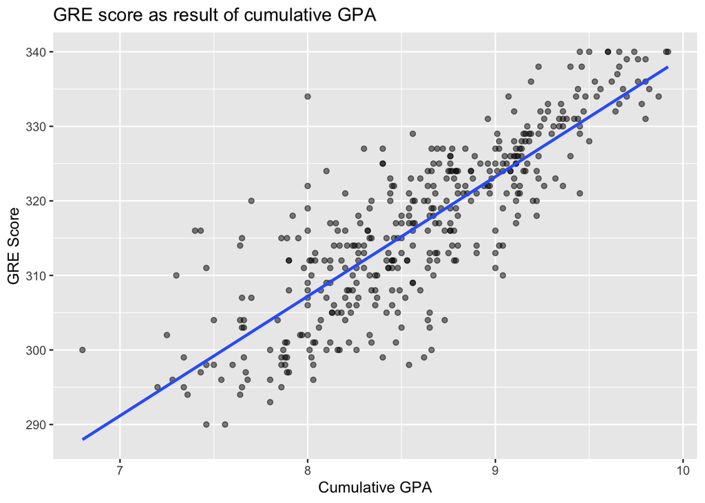

```r
ggplot(admissions_data, aes(x = cgpa, y = gre)) +
  xlab("Cumulative GPA") +
  ylab("GRE Score") +
  labs(title = "GRE score as result of cumulative GPA") +
  geom_point(alpha = 0.5) +
  geom_smooth(method="lm",se=FALSE)
```

```r
gpa_model <- lm(gre ~ cgpa, admissions_data)

#gpa_table <- get_regression_table(gpa_model)
#gpa_table

gpa_regression_summary <- get_regression_summaries(gpa_model)
gpa_regression_summary
```

```
## # A tibble: 1 x 8
##   r_squared adj_r_squared   mse  rmse sigma statistic p_value    df
##       <dbl>         <dbl> <dbl> <dbl> <dbl>     <dbl>   <dbl> <dbl>
## 1     0.694         0.693  40.2  6.34  6.36      903.       0     2
```

```r
admissions_data %>%
  select(cgpa, gre) %>%
  cor()
```

```
##           cgpa       gre
## cgpa 1.0000000 0.8330605
## gre  0.8330605 1.0000000
```

```r
# hmmm...
```

#### Q7 Response:

Cumulative GPA is not a great predictor of GRE score. When running a regression summary on the linear model for the two, we see that r squared is 69.4%, which shows that there is a fair amount of variance not being captured.

### Question 8 (15 points)

Which is more important (for the purposes of being admitted): (a) to have a strong letter of reference or (b) to have a strong statement of purpose? Explain your answer.

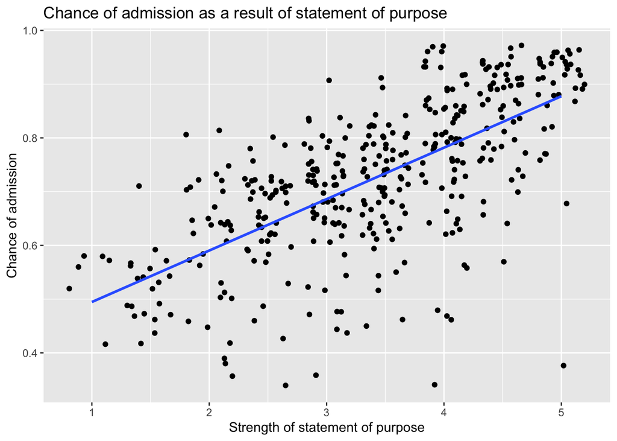

```r
ggplot(admissions_data, aes(x = sop, y = admit)) +
  geom_jitter() +
  xlab("Strength of statement of purpose") +
  ylab("Chance of admission") +
  labs(title = "Chance of admission as a result of statement of purpose") +
  geom_smooth(method="lm",se=FALSE)
```

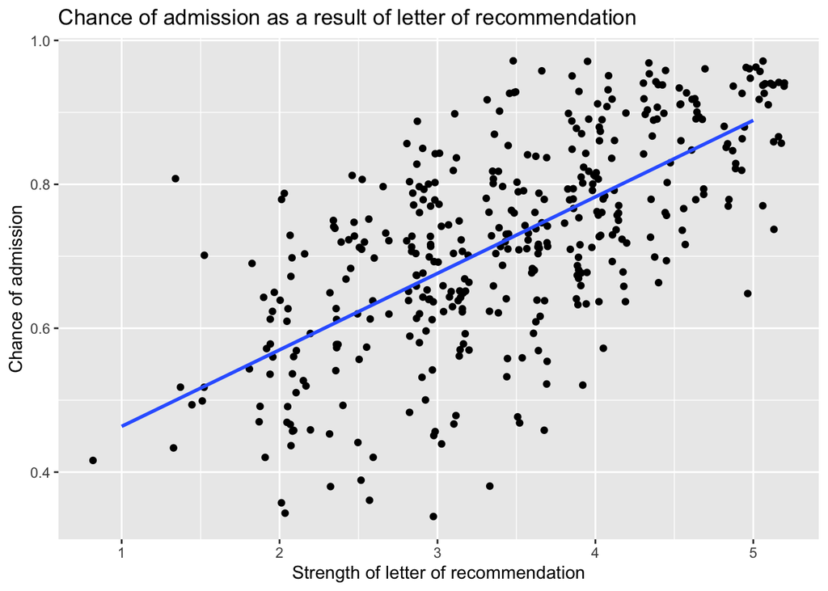

```r
ggplot(admissions_data, aes(x = lor, y = admit)) +
  geom_jitter() +
  xlab("Strength of letter of recommendation") +
  ylab("Chance of admission") +
  labs(title = "Chance of admission as a result of letter of recommendation") +
  geom_smooth(method="lm",se=FALSE)
```

```r
sop_regression_table <- get_regression_table(lm(admit ~ sop, admissions_data))
sop_regression_table
```

```
## # A tibble: 2 x 7
##   term      estimate std_error statistic p_value lower_ci upper_ci
##   <chr>        <dbl>     <dbl>     <dbl>   <dbl>    <dbl>    <dbl>
## 1 intercept    0.399     0.019      21.5       0    0.362    0.435
## 2 sop          0.096     0.005      18.3       0    0.085    0.106
```

```r
lor_regression_table <- get_regression_table(lm(admit ~ lor, admissions_data))
lor_regression_table
```

```
## # A tibble: 2 x 7
##   term      estimate std_error statistic p_value lower_ci upper_ci
##   <chr>        <dbl>     <dbl>     <dbl>   <dbl>    <dbl>    <dbl>
## 1 intercept    0.357     0.021      17.0       0    0.316    0.399
## 2 lor          0.106     0.006      18         0    0.095    0.118
```

```r
sop_regression_summary <- get_regression_summaries(lm(admit ~ sop, admissions_data))
sop_regression_summary
```

```
## # A tibble: 1 x 8
##   r_squared adj_r_squared    mse  rmse sigma statistic p_value    df
##       <dbl>         <dbl>  <dbl> <dbl> <dbl>     <dbl>   <dbl> <dbl>
## 1     0.457         0.455 0.0110 0.105 0.105      334.       0     2
```

```r
lor_regression_summary <- get_regression_summaries(lm(admit ~ lor, admissions_data))
lor_regression_summary
```

```
## # A tibble: 1 x 8
##   r_squared adj_r_squared    mse  rmse sigma statistic p_value    df
##       <dbl>         <dbl>  <dbl> <dbl> <dbl>     <dbl>   <dbl> <dbl>
## 1     0.449         0.447 0.0112 0.106 0.106      324.       0     2
```

```r
admissions_data %>%
  select(admit, sop, lor) %>%
  cor()
```

```
##           admit       sop       lor
## admit 1.0000000 0.6757319 0.6698888
## sop   0.6757319 1.0000000 0.7295925
## lor   0.6698888 0.7295925 1.0000000
```

```r
admit_parallel_model <- lm(admit ~ lor + sop, admissions_data)
```

#### Q8 Response:

Both letters of recommendation and statements of purpose have relatively low r squared values as they correspond to chance of admission. r squared for sop = 45.7%, r sqaured for lor = 44.9%. Each’s correlation to chance of admission is relatively low as well. Based on their similarity, neither are more important for improving chance of admission. Or, you could say, each is the same importance. In any case, both pull less weight for chance of admission than other factors such as cumulative GPA or GRE score.